# From Casual to Causal

Lucy D’Agostino McGowan

## Causal questions

- The heart of causal analysis is the causal question.
- It dictates data analysis, methods, and target populations.

## Goals of data analysis

Causal questions are part of a broader set of questions we can ask with statistical techniques related to the primary tasks of data science:

### description

### prediction

### causal inference

## Goals of data analysis

- The goal is often muddled by both the techniques we use (regression, for instance, is helpful for all three tasks) and the way we talk about them.
- When researchers are interested in causal inference from non-randomized data, we often use euphemistic language like *“association”* instead of declaring our intent to estimate a causal effect

Haber et al. 2022. “Causal and Associational Language in Observational Health Research: A Systematic Evaluation.” Am J Epidemiol 191 (12): 2084–97.

## Schrödinger’s Causality

- “Associate” most common root word for effects.
- Only 1% used “cause.”
- Action recommendations in 33% of studies.
- Stronger action recommendations than implied by effect description.
- Only 4% used formal causal models.

Haber et al. 2022. “Causal and Associational Language in Observational Health Research: A Systematic Evaluation.” Am J Epidemiol 191 (12): 2084–97.

## Schrödinger’s Causality

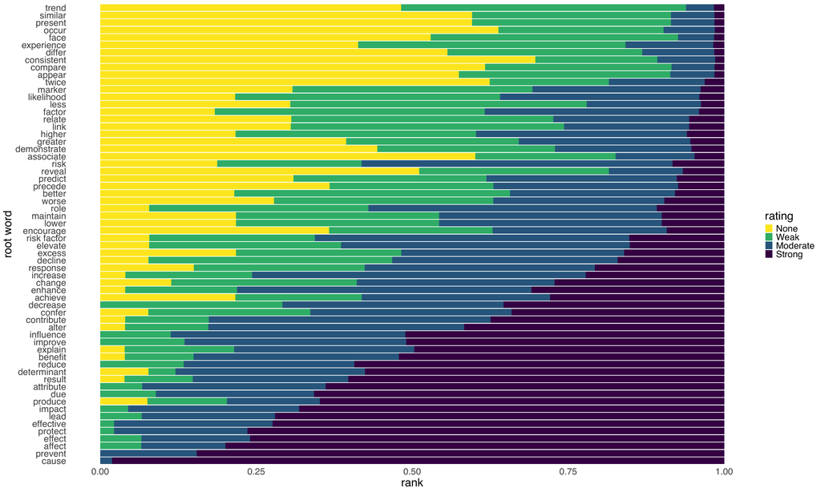

Haber et al. 2022. “Causal and Associational Language in Observational Health Research: A Systematic Evaluation.” Am J Epidemiol 191 (12): 2084–97.

# “Our results suggest that *Schrödinger’s causal inference* - where studies avoid stating (or even explicitly deny) an interest in estimating causal effects yet are otherwise embedded with causal intent, inference, implications, and recommendations - is common.”

Haber et al. 2022. “Causal and Associational Language in Observational Health Research: A Systematic Evaluation.” Am J Epidemiol 191 (12): 2084–97.

## Goals of data analysis

### description

### prediction

### causal inference

## Goals of data analysis

### description

### prediction

### causal inference

## Goals of data analysis

### description

*What* phenomena occur / occurred in the past?

- What is the prevalence of diabetes in the United States?
- What are the demographics of our customers?

### prediction

### causal inference

## Goals of data analysis

### description

*What* phenomena occur / occurred in the past?

*Validity concerns*: Measurement error, sampling error

*Connection to causal inference*: Understanding population characteristics, examining outcome distributions, checking if data structure matches research question

### prediction

### causal inference

## Goals of data analysis

### description

*What* phenomena occur / occurred in the past?

*Validity concerns*: Measurement error, sampling error

*Connection to causal inference*: Understanding population characteristics, examining outcome distributions, checking if data structure matches research question

### prediction

*Whether* a certain phenomena will occur given a set of circumstances

*Validity concerns*: Predictive accuracy, measurement error

*Connection to causal inference*: Some techniques use model predictions to answer causal questions

### causal inference

## Goals of data analysis

### description

*What* phenomena occur / occurred in the past?

*Validity concerns*: Measurement error, sampling error

*Connection to causal inference*: Understanding population characteristics, examining outcome distributions, checking if data structure matches research question

### prediction

*Whether* a certain phenomena will occur given a set of circumstances

*Validity concerns*: Predictive accuracy, measurement error

*Connection to causal inference*: Some techniques use model predictions to answer causal questions

### causal inference

*Why* does a phenomena occur

*Validity concerns*: Lots of assumptions (many that cannot be checked, coming soon!)

## Why Prediction ≠ Causation

Predictive power **doesn’t guarantee causal accuracy**, especially when:

- The outcome has many causes but the model focuses on one exposure
- The true causal effect is small
- The model excludes non-causal predictors for methodological reasons

## The Ice Cream & Crime Example

- You have ice cream sales data but no weather data
- Ice cream sales correlate with crime rates and can predict them moderately well – suppose this correlation exists because both variables are caused by weather!

**Variables that are invalid from a causal perspective (like ice cream sales) can still provide predictive power by acting as proxies for true causal factors (like weather)**

# The first step is asking a good causal question

## Diagramming causal claims

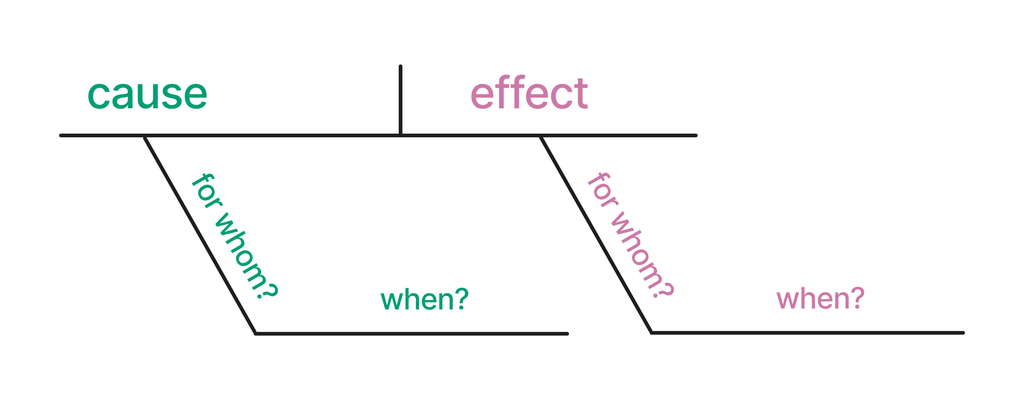

## Smoking causes lung cancer

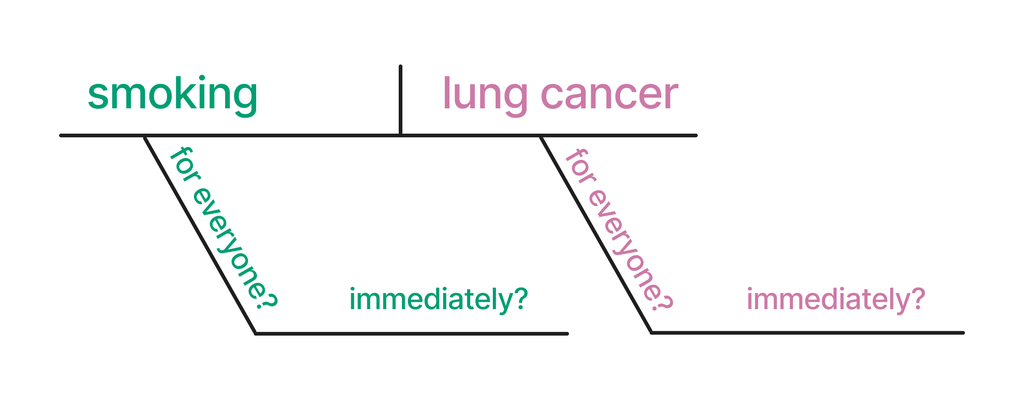

# Let’s try to get more specific

[figure not shown]

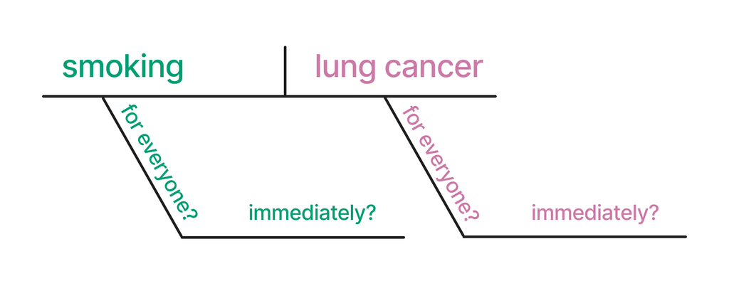

[figure not shown]

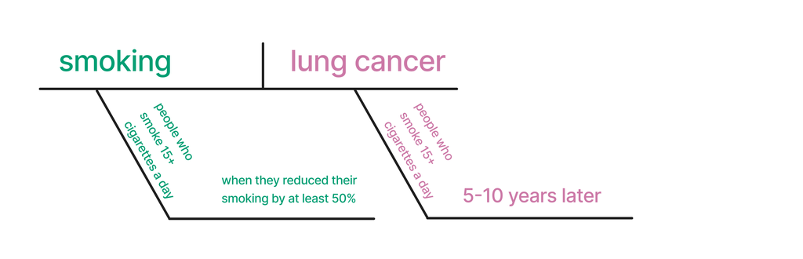

## Target Trial

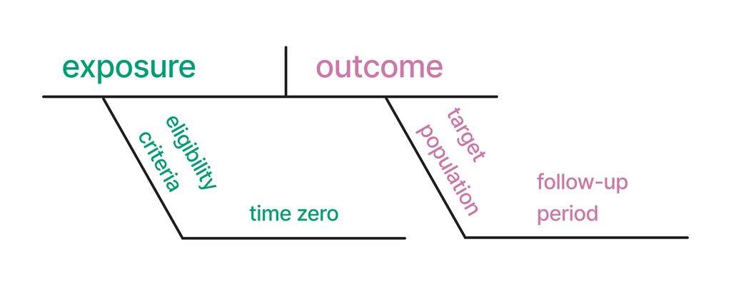

## Asking good causal questions

### **The claim**

### **The evidence**

## Asking good causal questions

### **The claim**

Smoking causes lung cancer

### **The evidence**

For people who smoking 15+cigarettes a day, reducing smoking by 50% reduces the risk of lung cancer over 5-10 years

## Asking good causal questions

### **The question**

Does smoking causes lung cancer?

### **The evidence**

For people who smoking 15+cigarettes a day, reducing smoking by 50% reduces the risk of lung cancer over 5-10 years

## Asking good causal questions

### **The question**

For people who smoke 15+ cigarettes a day, does reducing smoking by 50% reduce the lung cancer risk over 5-10 years?

### **The evidence**

For people who smoking 15+cigarettes a day, reducing smoking by 50% reduces the risk of lung cancer over 5-10 years